# **Chapter3:Logistic Regression**

#Heidi Hirvonen 18.11.2020

**1.** First, I created the Rmd file, Chapter3 and added it as a child file in the index.Rmd.

**2.** Next, I will read the joined student alcohol consumption data into R from https://github.com/rsund/IODS-project/raw/master/data/alc.csv

- Then I will print out the names of the variables in the data with the colnames() function and describe the dataset

```r
joined_data <- read.csv("https://github.com/rsund/IODS-project/raw/master/data/alc.csv", sep=",", header=TRUE)

colnames(joined_data)
```

```
##  [1] "school"     "sex"        "age"        "address"    "famsize"
##  [6] "Pstatus"    "Medu"       "Fedu"       "Mjob"       "Fjob"
## [11] "reason"     "guardian"   "traveltime" "studytime"  "schoolsup"
## [16] "famsup"     "activities" "nursery"    "higher"     "internet"
## [21] "romantic"   "famrel"     "freetime"   "goout"      "Dalc"
## [26] "Walc"       "health"     "n"          "id.p"       "id.m"
## [31] "failures"   "paid"       "absences"   "G1"         "G2"
## [36] "G3"         "failures.p" "paid.p"     "absences.p" "G1.p"
## [41] "G2.p"       "G3.p"       "failures.m" "paid.m"     "absences.m"
## [46] "G1.m"       "G2.m"       "G3.m"       "alc_use"    "high_use"
## [51] "cid"
```

- This data measures student achievement in secondary education of two Portuguese schools.The data attributes include student grades, demographic, social and school related features and it was collected by using school reports and questionnaires.The original source of this data is https://archive.ics.uci.edu/ml/datasets/Student+Performance*

**3.** Next I will analyze the relationships between high/low alcohol consumption and some of the other variables in the data.

- **My assumption is that high alcohol use could negatively affect current health status and also be connected to a higher number of school absences.**
- **Again, I think that family educational support & extra-curricular activities would negatively affect high alcohol use.**

**4.** First, I will access the tidyverse libraries tidyr, dplyr and ggplot2. Then I will numerically and graphically explore the distributions of my chosen variables and alcohol use (crosstabulations, barplots & boxplots)

```r
library(tidyr)

library(dplyr)
```

```r
library(ggplot2)

glimpse(joined_data)
```

```
## Rows: 370
## Columns: 51
## $ school     <chr> "GP", "GP", "GP", "GP", "GP", "GP", "GP", "GP", "GP", "GP",…
## $ sex        <chr> "F", "F", "F", "F", "F", "F", "F", "F", "F", "F", "F", "F",…
## $ age        <int> 15, 15, 15, 15, 15, 15, 15, 15, 15, 15, 15, 15, 15, 15, 15,…
## $ address    <chr> "R", "R", "R", "R", "R", "R", "R", "R", "R", "U", "U", "U",…
## $ famsize    <chr> "GT3", "GT3", "GT3", "GT3", "GT3", "GT3", "GT3", "LE3", "LE…
## $ Pstatus    <chr> "T", "T", "T", "T", "T", "T", "T", "T", "T", "A", "A", "T",…
## $ Medu       <int> 1, 1, 2, 2, 3, 3, 3, 2, 3, 3, 4, 1, 1, 1, 1, 1, 2, 2, 2, 3,…
## $ Fedu       <int> 1, 1, 2, 4, 3, 4, 4, 2, 1, 3, 3, 1, 1, 1, 2, 2, 1, 2, 3, 2,…
## $ Mjob       <chr> "at_home", "other", "at_home", "services", "services", "ser…
## $ Fjob       <chr> "other", "other", "other", "health", "services", "health", …
## $ reason     <chr> "home", "reputation", "reputation", "course", "reputation",…
## $ guardian   <chr> "mother", "mother", "mother", "mother", "other", "mother", …
## $ traveltime <int> 2, 1, 1, 1, 2, 1, 2, 2, 2, 1, 1, 3, 1, 1, 1, 1, 3, 1, 2, 1,…
```

[output cut: 38 more lines]

```r
gather(joined_data) %>% glimpse
```

```
## Rows: 18,870
## Columns: 2
## $ key   <chr> "school", "school", "school", "school", "school", "school", "sch…
## $ value <chr> "GP", "GP", "GP", "GP", "GP", "GP", "GP", "GP", "GP", "GP", "GP"…
```

- First let’s look at high alcohol use and current health status. Quite surprisingly it looks like students with high use of alcohol, have a better mean health (3,73) than the ones who use less alcohol(3,49). Obviously I do not see a causal connection here.

```r
#Produce summary statistics of high_use and health
joined_data %>% group_by(high_use) %>% summarise(count = n(),mean(health))
```

```
## # A tibble: 2 x 3
##   high_use count `mean(health)`
##   <lgl>    <int>          <dbl>
## 1 FALSE      259           3.49
## 2 TRUE       111           3.73
```

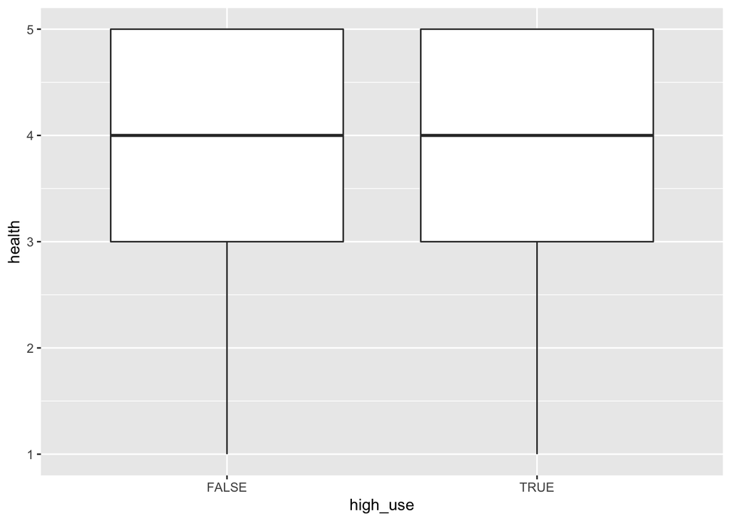

```r
# initialize a plot of high_use and health
a1 <- ggplot(joined_data, aes(x = high_use, y = health))

# define the plot as a boxplot and draw it
a1 + geom_boxplot()+ xlab("high_use") + ylab("health")
```

Second, let’s take a look at high alcohol use and absences. - The connection between absences and high alcohol use are as I expected. Mean absences for the students with high alcohol use is 6,38 days and ones with less alcohol use is 3,71 days.

```r
#Produce summary statistics of high_use and absences
joined_data %>% group_by(high_use) %>% summarise(count = n(),mean(absences))
```

```
## # A tibble: 2 x 3
##   high_use count `mean(absences)`
##   <lgl>    <int>            <dbl>
## 1 FALSE      259             3.71
## 2 TRUE       111             6.38
```

[figure not shown]

```r
# initialize a plot of high_use and absences
a2 <- ggplot(joined_data, aes(x = high_use, y = absences))

# define the plot as a boxplot and draw it
a1 + geom_boxplot() +  xlab("high_use") + ylab("absences")
```

- Third let’s have a look at high alcohol use and family support & extra curricular activities. As I expected family educational support and extra curricular activities are negatively correlated with high alcohol use.

```r
#Produce summary statistics of family support and high alcohol use
joined_data %>% group_by(famsup) %>% summarise(count = n(),mean(high_use))
```

```
## # A tibble: 2 x 3
##   famsup count `mean(high_use)`
##   <chr>  <int>            <dbl>
## 1 no       139            0.324
## 2 yes      231            0.286
```

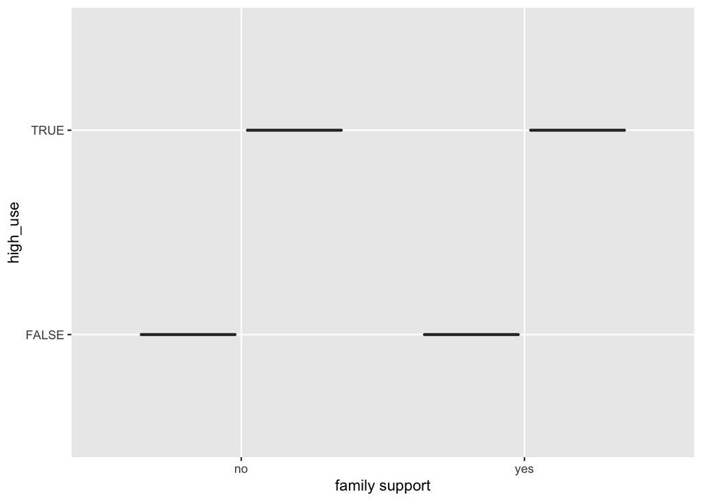

```r
# initialize a plot of high_use and health
a3 <- ggplot(joined_data, aes(x = famsup, y = high_use))

# define the plot as a boxplot and draw it
a3 + geom_boxplot() +  xlab("family support") + ylab("high_use")
```

```r
#Produce summary statistics of extra curricular activities and high alcohol use
joined_data %>% group_by(activities) %>% summarise(count = n(),mean(high_use))
```

```
## # A tibble: 2 x 3
##   activities count `mean(high_use)`
##   <chr>      <int>            <dbl>
## 1 no           179            0.330
## 2 yes          191            0.272
```

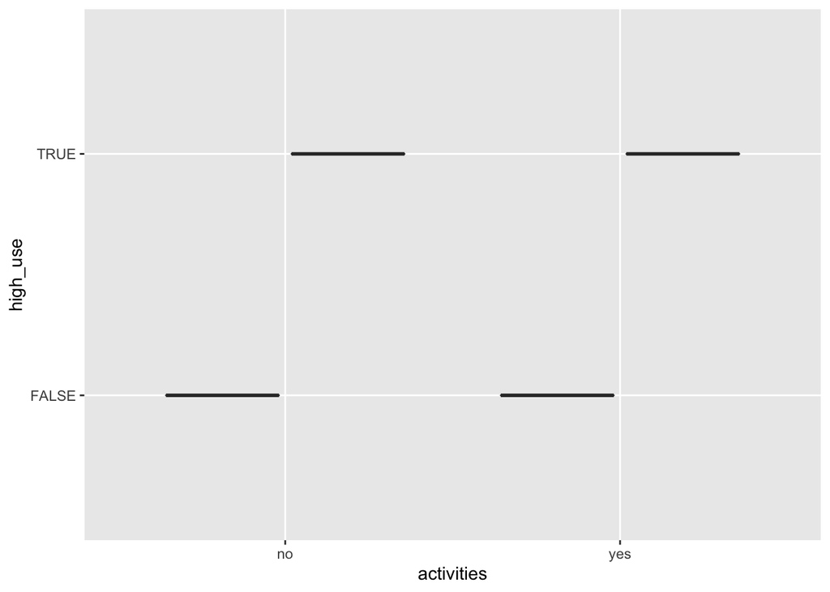

```r
# initialize a plot of high_use and absences
a4 <- ggplot(joined_data, aes(x = activities, y = high_use))

# define the plot as a boxplot and draw it
a4 + geom_boxplot() + xlab("activities")+ ylab("high_use")
```

**5.** Next, I am using logistic regression to statistically explore the relationship between my chosen variables and the binary high/low alcohol consumption variable as the target variable. I will present and interpret the coefficients of the models as odds ratios and provide confidence intervalls for them

```r
#regression
m <- glm(high_use ~ health + absences + famsup + activities, data = joined_data , family = "binomial")
summary(m)
```

```
##
## Call:
## glm(formula = high_use ~ health + absences + famsup + activities,
##     family = "binomial", data = joined_data)
##
## Deviance Residuals:
##     Min       1Q   Median       3Q      Max
## -2.5664  -0.8251  -0.7171   1.2578   1.9729
##
## Coefficients:
##               Estimate Std. Error z value Pr(>|z|)
## (Intercept)   -1.48808    0.39040  -3.812 0.000138 ***
## health         0.14099    0.08613   1.637 0.101637
## absences       0.08975    0.02315   3.877 0.000106 ***
## famsupyes     -0.23892    0.24092  -0.992 0.321337
## activitiesyes -0.29591    0.23480  -1.260 0.207580
## ---
## Signif. codes:  0 '***' 0.001 '**' 0.01 '*' 0.05 '.' 0.1 ' ' 1
##
## (Dispersion parameter for binomial family taken to be 1)
##
##     Null deviance: 452.04  on 369  degrees of freedom
## Residual deviance: 429.59  on 365  degrees of freedom
## AIC: 439.59
##
## Number of Fisher Scoring iterations: 4
```

```r
coef(m)
```

```
##   (Intercept)        health      absences     famsupyes activitiesyes
##   -1.48807647    0.14098501    0.08974717   -0.23892472   -0.29590959
```

```r
OR <- coef(m) %>% exp
CI <- confint(m) %>% exp
cbind(OR, CI)
```

```
##                      OR     2.5 %    97.5 %
## (Intercept)   0.2258066 0.1027826 0.4768908
## health        1.1514074 0.9747528 1.3673371
## absences      1.0938977 1.0475837 1.1472586
## famsupyes     0.7874742 0.4913683 1.2657321
## activitiesyes 0.7438547 0.4683710 1.1776531
```

As we can see from the regression coefficients, family support and extra curricular activities are negatively correlated with high alcohol use. On the other hand, good current health status and absences are positively correlated with high alcohol use. The only statistically signifigant result is the connection between high alcohol use and absences.

The knowledge I have on the data is not enough to make clear causal interpretations, although it might be tempting to claim that family support and extra curricular activities might lead to less alcohol consumption.

It is also not very surprising that absences and high alcohol consumption are posilively correlated, but it is more difficult to say which one is the cause and which one is the effect (or if there is some thirs variable causing both of these)

To me, the most surprising result is the fact that high alcohol consumption and good current health status are positively correlated. It might be that the possible health hazards of high alcohol use do not show, because the respondents are so young. I would still have thought that high alcohol use would have been connected with worse mental health also on young people. So I guess it all comes down to how the health status is measures. It might be that the youngsters with bad health do not want to risk it more by using alcohol.

```r
# fit the model
m <- glm(high_use ~ health + absences + famsup + activities , data = joined_data, family = "binomial")
# predict() the probability of high_use
probabilities <- predict(m, type = "response")
# add the predicted probabilities to 'joined_data'
joined_data <- mutate(joined_data, probability = probabilities)
# use the probabilities to make a prediction of high_use
joined_data <- mutate(joined_data, prediction = probability > 0.5)
# see the last ten original classes, predicted probabilities, and class predictions
select(joined_data, sex, age, goout, address, high_use, probability, prediction) %>% tail(10)
```

```
##     sex age goout address high_use probability prediction
## 361   M  18     3       R     TRUE   0.3924820      FALSE
## 362   M  18     3       R     TRUE   0.2090412      FALSE
## 363   M  18     1       R     TRUE   0.3535075      FALSE
## 364   M  18     4       U     TRUE   0.2417650      FALSE
## 365   M  18     2       U    FALSE   0.3109075      FALSE
## 366   M  18     3       U     TRUE   0.3304539      FALSE
## 367   M  18     2       U    FALSE   0.3136411      FALSE
## 368   M  19     4       R     TRUE   0.3400464      FALSE
## 369   M  19     4       R     TRUE   0.3803344      FALSE
## 370   M  19     2       R    FALSE   0.3136411      FALSE
```

```r
# tabulate the target variable versus the predictions
table(high_use = joined_data$high_use, prediction = joined_data$prediction)
```

```
##         prediction
## high_use FALSE TRUE
##    FALSE   251    8
##    TRUE     98   13
```